# Marketing_Email_Conversion_Analysis

### Introduction

The purpose of this notebook is to analyze Company X's email funnel for different customer populations and over time from a sample of email marketing campaign data. The client_id table contains a lookup for distinct clients whose employees can subscribe to Company X. The email_list table contains member level names, emails, and demographic information. The campaign table has information related to the campaign, like campaign date, which employer/client was targeted, and the email goal. The email summary table contains sent, opens, clicks and other related information for each recipient and campaign.

**Schemas:**

client_id:

- client_name (string): Name of employer
- client_id (string): Unique identifier for employer

email_list:

- member_id (string): Unique identifier for recipient
- first_name (string): Recipients’s first name
- last_name (string): Recipient’s last name
- email_id (string): Recipient’s email address
- gender (string): Recipient’s gender
- age (string): Recipient’s age
- client_id (string): Unique identifier for an employer
- unsubscribed (string): Indicates if a recipient has unsubscribed from receiving emails

campaign:

- campaign_name (string): Internal name of email campaign
- client_id (string): Unique identifier for an employer
- email_goal (string): Denotes what the campaign category and what type of engagement the campaign is looking to drive
- campaign_date (date): Date the campaign was sent to recipients

email_summary

- member_id (string): Unique identifier for a recipient
- campaign_id (string): Unique identifier for an email campaign
- sent (int): 1 - Recipient was sent an email, 0 - Recipient was not sent an email
- received (int): 1 - Recipient received the email, 0 - Recipient did not receive the email
- opened (int): Count of how many times a recipient opened the email
- clicked (int): Count of how many times a recipient clicked the email
- bounced (int): Indicator that the email was not received because it bounced
- first_opened_date (date): Indicates when an email was first opened
- last_opened_date (date): Indicates when an email was last opened
- first_clicked_date (date): Indicates when an email was first clicked
- last_clicked_date (date): Indicates when an email was last clicked

### Import Data and Clean

The below code imports the csv files, merges them and does the necessary cleaning and feature engineering to conudct relevant analysis.

```python
import pandas as pd
import numpy as np
import pylab as pl
from scipy.stats import chi2_contingency
```

```python
campaign = pd.read_csv("campaign.csv")
client_id = pd.read_csv("client_id.csv")
email_list = pd.read_csv("email_list.csv")
email_summary = pd.read_csv("email_summary.csv")
```

```python
email_summary.head()
```

|  | member_id | campaign_id | sent | received | opened | clicked | bounced | first_opened_date | last_opened_date | first_clicked_date | last_clicked_date |
| --- | --- | --- | --- | --- | --- | --- | --- | --- | --- | --- | --- |
| 0 | 745f9cd7-2ba3-45fe-b89e-497a4e902e27 | 5a2b492a-0a0d-4f93-89b2-6ab08ad57616 | 0 | 0 | 0 | 0 | 0 | NaN | NaN | NaN | NaN |
| 1 | 1a1f67f4-1d33-4150-af52-5c46a251ff19 | 3fc29b6b-4a73-483c-b7a9-4b094978bbab | 1 | 1 | 0 | 0 | 0 | NaN | NaN | NaN | NaN |
| 2 | e69baabf-f06b-4865-9b45-b50d84447e67 | 46945f17-bf89-48b8-8300-7e260216ca7f | 0 | 0 | 0 | 0 | 0 | NaN | NaN | NaN | NaN |
| 3 | 77a831e9-c871-42a1-ae21-05208fdf780a | ce17192f-345c-402f-8066-403b1bd63660 | 1 | 1 | 3 | 2 | 0 | 11/16/2021 | 11/16/2021 | 11/16/2021 | 11/19/2021 |
| 4 | 1fe90fd1-b3e8-454f-8655-2a75df0ef15f | 841ead87-6f10-4ab0-89bf-e972e94e1b20 | 0 | 0 | 0 | 0 | 0 | NaN | NaN | NaN | NaN |

```python
# merge email_summary with email_list
df = email_summary.merge(email_list, on="member_id", how = 'left')
```

```python
# merge with campaign
df = df.merge(campaign, on="campaign_id", how = 'left')
```

```python
# add variables indicating whether employee opened/clicked email at least once
df["opened_once"] = 0
df.loc[((df['opened'] >= 1) & (df['received'] == 1)),"opened_once"] = 1

df["clicked_once"] = 0
df.loc[((df['clicked'] >= 1) & (df['received'] == 1)),"clicked_once"] = 1
```

```python
# declare date variables as datetime
df["campaign_date"] = pd.to_datetime(df["campaign_date"])
df["first_opened_date"] = pd.to_datetime(df["first_opened_date"])
df["last_opened_date"] = pd.to_datetime(df["last_opened_date"])
df["first_clicked_date"] = pd.to_datetime(df["first_clicked_date"])
df["last_clicked_date"] = pd.to_datetime(df["last_clicked_date"])
```

```python
# add variable for # of days to open and from open to click
df['days_to_open'] = (df['first_opened_date'] - df['campaign_date']).dt.days
df['days_to_click'] = (df['first_clicked_date'] - df['campaign_date']).dt.days
df['days_open_to_click'] = (df['first_clicked_date'] - df['first_opened_date']).dt.days
```

In order to analyze engagement by age, I decided to look at the age distribution of the population to see if binning was appropriate. Because of the wide range of ages, I decided that binning in 5 year increments would enable efficient age level analysis.

```
26.0
48.0
```

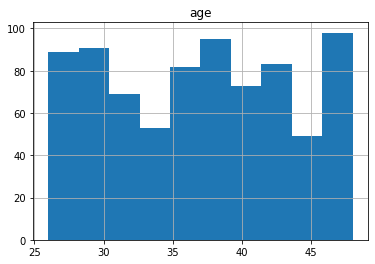

```python
df.hist("age")
print(min(df["age"]))
print(max(df["age"]))
```

```python
df['age_group'] = pd.cut(df['age'], bins=[25, 30, 35, 40, 45, float('Inf')], labels=['25-30', '31-35', '36-40','41-45','46+'])
```

```python
def open_rate(df) :
    return round(sum(df["opened_once"])/sum(df["received"]),2)

def click_rate(df) :
    return round(sum(df["clicked_once"])/sum(df["received"]),2)

def opened_and_clicked(df):
    return round((sum(df["clicked_once"])/sum(df["opened_once"])),2)
```

The following tables analyze the email funnel (e.g. rates of opening and clicking on email) by gender and age groups. They include only people that have received an email (received = 1). Opened rate is defined as number of people who opened an email divided by number of people that received an email. Clicked rate is defined as number of people that clicked an email divided by number of people that received an email. Opened_and_clicked is defined as the number of people that clicked an email divided by the number of people that opened an email.

```python
df.groupby(['gender','age_group']).agg({"received":np.sum,"opened_once":np.sum, "clicked_once":np.sum})
```

| gender | age_group | received | opened_once | clicked_once |
| --- | --- | --- | --- | --- |
| F | 25-30 | 18 | 17 | 14 |
|  | 31-35 | 6 | 3 | 2 |
|  | 36-40 | 15 | 9 | 7 |
|  | 41-45 | 23 | 15 | 13 |
|  | 46+ | 12 | 8 | 8 |
| M | 25-30 | 14 | 11 | 5 |
|  | 31-35 | 13 | 8 | 6 |
|  | 36-40 | 13 | 9 | 5 |
|  | 41-45 | 20 | 16 | 10 |
|  | 46+ | 7 | 7 | 6 |

```python
print("Open Rate by Gender and Age Group")
df.groupby(['gender','age_group']).apply(open_rate)
```

```
Open Rate by Gender and Age Group
```

```
gender  age_group
F       25-30        0.94
        31-35        0.50
        36-40        0.60
        41-45        0.65
        46+          0.67
M       25-30        0.79
        31-35        0.62
        36-40        0.69
        41-45        0.80
        46+          1.00
dtype: float64
```

```python
print("Click Rate by Gender and Age Group")
df.groupby(['gender','age_group']).apply(click_rate)
```

```
Click Rate by Gender and Age Group
```

```
gender  age_group
F       25-30        0.78
        31-35        0.33
        36-40        0.47
        41-45        0.57
        46+          0.67
M       25-30        0.36
        31-35        0.46
        36-40        0.38
        41-45        0.50
        46+          0.86
dtype: float64
```

```python
print("Open and Click Rate by Gender and Age Group")
df.groupby(['gender','age_group']).apply(opened_and_clicked)
```

```
Open and Click Rate by Gender and Age Group
```

```
gender  age_group
F       25-30        0.82
        31-35        0.67
        36-40        0.78
        41-45        0.87
        46+          1.00
M       25-30        0.45
        31-35        0.75
        36-40        0.56
        41-45        0.62
        46+          0.86
dtype: float64
```

```python
for test in [('gender','open'), ('gender','click'), ('age_group','open'), ('age_group','click')] :
    if test[1] == 'open' :
        met = 'opened_once'
    else :
        met = 'clicked_once'
    table = pd.crosstab(df[test[0]], df[met])
    c, p, dof, expected = chi2_contingency(table)
    if p > .05 :
        print("Variances of {metric} rates for different {groups}s are not significant, with a P value of {pval}".format(
        metric = test[1], groups = test[0], pval = round(p,2)))
    else :
        print("Variances of {metric} rates for different {groups}s are significant, with a P value of {pval}".format(
        metric = test[1], groups = test[0], pval = round(p,2)))
```

```
Variances of open rates for different genders are not significant, with a P value of 0.39
Variances of click rates for different genders are not significant, with a P value of 0.57
Variances of open rates for different age_groups are not significant, with a P value of 0.16
Variances of click rates for different age_groups are not significant, with a P value of 0.15
```

To explore temporal patterns associated with click-through rates, I ran descriptive statistics on the number of days until a person opens and clicks an email (from when they received it and from when they opened it), and created histograms to look at the distribution.

On average, it takes people about 4 days to open an email, with a minimum of 0 days (some people open it the day they get it) and a maximum of 9 days (no one opens the email after 9 days).

Most people click on an email within a week of getting it and within a day of opening it, with a few clicking as far as 16 days out from receipt and a week out from opening. The average across all persons is 5 days from receipt and just under a day from opening.

```
Days to Open Statistics:
Average Days to Open:  4.16
```

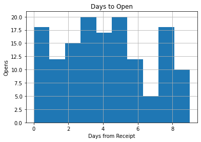

```python
print("Days to Open Statistics:")
print("Average Days to Open: ", round(np.mean(df["days_to_open"]),2))
df["days_to_open"].describe()
df.hist("days_to_open")
pl.title("Days to Open")
pl.xlabel("Days from Receipt")
pl.ylabel("Opens")
```

```
Days to Click Statistics:
Average Days to Click:  5.0
```

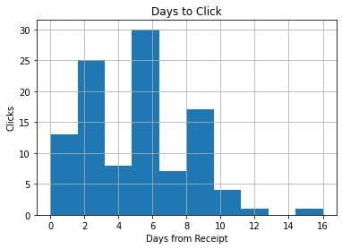

```python
print("Days to Click Statistics:")
print("Average Days to Click: ", round(np.mean(df["days_to_click"]),2))
df["days_to_click"].describe()
df.hist("days_to_click")
pl.title("Days to Click")
pl.xlabel("Days from Receipt")
pl.ylabel("Clicks")
```

```
Days from Open to Click Statistics:
Average Days from Open to Click:  0.77
```

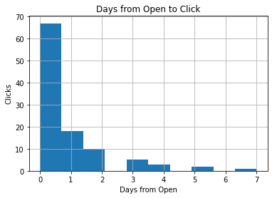

```python
print("Days from Open to Click Statistics:")
print("Average Days from Open to Click: ", round(np.mean(df["days_open_to_click"]),2))
df["days_open_to_click"].describe()
df.hist("days_open_to_click")
pl.title("Days from Open to Click")
pl.xlabel("Days from Open")
pl.ylabel("Clicks")
```

I also wanted to see if there was any correlation between the month or day of the week the email was sent. Based on the p-value of the Chi-squared tests (0.91 for different months and 0.09 for different days of the week), there is no significant difference between click-through rates in different months or on different days.

```python
df['campaign_weekday'] = df['campaign_date'].dt.day_name()
df['campaign_month'] = df['campaign_date'].dt.month
```

```python
for test in [('campaign_month','click'),('campaign_month','open'),('campaign_weekday','open'),('campaign_weekday','click')] :
    if test[1] == 'open' :
        met = 'opened_once'
    else :
        met = 'clicked_once'
    table = pd.crosstab(df[test[0]], df[met])
    c, p, dof, expected = chi2_contingency(table)
    if p > .05 :
        print("Variances of {metric} rates for different {groups}s are not significant, with a P value of {pval}".format(
        metric = test[1], groups = test[0], pval = round(p,2)))
    else :
        print("Variances of {metric} rates for different {groups}s are significant, with a P value of {pval}".format(
        metric = test[1], groups = test[0], pval = round(p,2)))
```

```
Variances of click rates for different campaign_months are not significant, with a P value of 0.91
Variances of open rates for different campaign_months are not significant, with a P value of 0.63
Variances of open rates for different campaign_weekdays are not significant, with a P value of 0.25
Variances of click rates for different campaign_weekdays are not significant, with a P value of 0.09
```

### Further Analysis

Further analysis could include analyzing these same metrics and trends at the campaign, employer and email goal level. This could answer questions such as "does activation, enrollment, followup or re-activation emails get the highest engagement?" or "what employers have the highest engagements?". Based on this information, increased focus could be given to low-engagement employers or additional services/products could be advertised to high-engagement employers. And if re-activation emails had very low click-through rates, perhaps changing the strategy to re-activate customers would be appropriate.

There were no significant differences over time or for different populations of customers for open and click rates according to the Chi-squared tests. However, the dataset was relatively short, and more data might lead to more significant variations. Knowing that certain age groups or genders engage more with emails could inform marketing and communications strategies.

### Note on the data

I noticed that some of the campaign_ids were associated with a different client_id in the email_summary csv and in the campaign csv. For example, Jane Doe (member_id d2ad44e4-3404-4365-9158-935ee145700b) works for client_id 0fdb500c-33a7-40cc-926c-ad4e906ed577 and was sent campaign_id 3fc29b6b-4a73-483c-b7a9-4b094978bbab which is associated with client_id 0fdb500c-33a7-40cc-926c-ad4e906ed580 in the campaign table. This didn't impact any of the above analysis but led me to focus on different age and gender segments instead of employer or campaign level populations.